# RNAseq L. boulardi/LbFV : wasp side

julien.varaldi@univ-lyon1.fr

14 février 2018

# 1 import data

```r
countData <- (read.table("../data/gene_count_matrix.csv", h=T))
dim(countData)
```

```
## [1] 16787    32
```

```r
head(countData)
```

```
##      G495IA1 G495IA2 G495IH1 G495IH2 G495UIA1 G495UIA2 G495UIH1 G495UIH2
## ORF1       6       4       2       4        0        0        0        0
## ORF2       0       0       0       1        0        0        0        0
## ORF3       0       0       1       0        0        0        0        0
## ORF4      39      19      17      17        0        0        0        0
## ORF5       5       1       1       2        0        0        0        0
## ORF6       0       0       0       0        0        0        0        0
##      Lb84IA1 Lb84IA2 Lb84IH1 Lb84IH2 Lb84UIA1 Lb84UIA2 Lb84UIH1 Lb84UIH2
## ORF1       2       8       6       5        0        0        0        0
## ORF2       0       0       0       0        0        0        0        0
## ORF3       0       3       0       0        0        0        0        0
## ORF4      31      64      40      36        0        0        0        0
## ORF5       8       5       6       2        0        0        0        0
## ORF6       0       0       0       0        0        0        0        0
##      SiennaIA1 SiennaIA2 SiennaIH1 SiennaIH2 SiennaUIA1 SiennaUIA2
## ORF1         2         7         6        13          0          0
## ORF2         0         0         0         0          0          0
## ORF3         2         1         0         1          0          0
## ORF4        31        51        27        25          0          0
## ORF5         7        14         1         1          0          0
## ORF6         1         1         0         0          0          0
##      SiennaUIH1 SiennaUIH2 StFoyIA1 StFoyIA2 StFoyIH1 StFoyIH2 StFoyUIA1
## ORF1          0          0        9        6        3       11         0
## ORF2          0          0        0        0        0        0         0
## ORF3          0          0        1        3        0        0         0
## ORF4          0          0       49       43       34       27         0
## ORF5          0          0        6       15        0        0         0
## ORF6          0          0        0        2        0        0         0
##      StFoyUIA2 StFoyUIH1 StFoyUIH2
## ORF1         0         0         0
## ORF2         0         0         0
## ORF3         0         0         0
## ORF4         0         0         0
## ORF5         0         0         0
## ORF6         0         0         0
```

```r
sample_info=read.table("../data/sample_information.txt", h=T)
sample_info
```

```
##          name genotype tissue infection sample
## 1     G495IA1     G495      A         I     31
## 2     G495IA2     G495      A         I     32
## 3     G495IH1     G495      H         I     34
## 4     G495IH2     G495      H         I     35
## 5    G495UIA1     G495      A        UI     13
## 6    G495UIA2     G495      A        UI     14
## 7    G495UIH1     G495      H        UI     16
## 8    G495UIH2     G495      H        UI     17
## 9     Lb84IA1     Lb84      A         I     25
## 10    Lb84IA2     Lb84      A         I     26
## 11    Lb84IH1     Lb84      H         I     28
## 12    Lb84IH2     Lb84      H         I     29
## 13   Lb84UIA1     Lb84      A        UI      7
## 14   Lb84UIA2     Lb84      A        UI      8
```

[output cut: 18 more lines]

# 2 Mapping statistics

```r
tab=read.table("../data/hisat2_summary_stats.txt", h=T)
head(tab)
```

```
##   sample    reads aln_one_time overall_rate
## 1     10 11120112      8949811        86.27
## 2     11 11138233      9071773        87.15
## 3     13 10028949      9029641        96.17
## 4     14 18359712     16629903        96.62
## 5     16 13415392     11974652        95.76
## 6     17 12198937     10842094        95.56
```

```r
stats=merge (sample_info, tab)
stats
```

```
##    sample       name genotype tissue infection    reads aln_one_time
## 1       1  StFoyUIA1    StFoy      A        UI  7215676      6625848
## 2       2  StFoyUIA2    StFoy      A        UI 10306344      9488834
## 3       4  StFoyUIH1    StFoy      H        UI 12880938     11620960
## 4       5  StFoyUIH2    StFoy      H        UI 11261987     10135247
## 5       7   Lb84UIA1     Lb84      A        UI  6547172      5967180
## 6       8   Lb84UIA2     Lb84      A        UI 13467108     12170439
## 7      10   Lb84UIH1     Lb84      H        UI 11120112      8949811
## 8      11   Lb84UIH2     Lb84      H        UI 11138233      9071773
## 9      13   G495UIA1     G495      A        UI 10028949      9029641
## 10     14   G495UIA2     G495      A        UI 18359712     16629903
## 11     16   G495UIH1     G495      H        UI 13415392     11974652
## 12     17   G495UIH2     G495      H        UI 12198937     10842094
## 13     19   StFoyIA1    StFoy      A         I 17302172     15775421
## 14     20   StFoyIA2    StFoy      A         I 15765675     14380902
```

[output cut: 51 more lines]

## 2.1 plot overall alignment rate

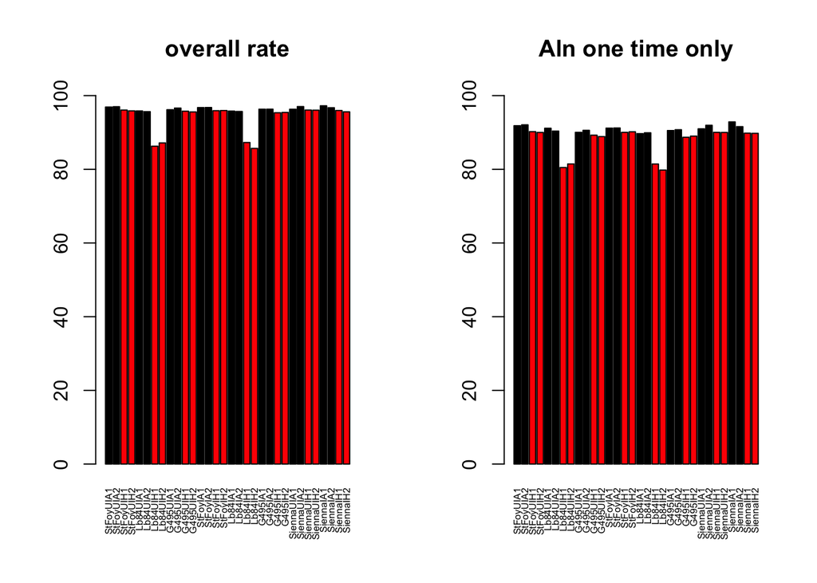

```r
par (mfrow=c(1,2))
barplot(stats$overall_rate, col=stats$tissue, names.arg = stats$name, las=3, ylim=c(0,100), main="overall rate", cex.names = 0.5)
barplot(stats$aln_one_time/stats$reads*100, col=stats$tissue, names.arg = stats$name, las=3, ylim=c(0,100), main="Aln one time only",cex.names = 0.5)
```

```r
par (mfrow=c(1,1))
```

## 2.2 Test for factors affecting the mapping process

```r
anova(lm(asin(sqrt(stats$overall_rate/100))~stats$genotype+stats$tissue+stats$infection))
```

```
## Analysis of Variance Table
##
## Response: asin(sqrt(stats$overall_rate/100))
##                 Df   Sum Sq   Mean Sq F value    Pr(>F)
## stats$genotype   3 0.056592 0.0188641 15.3113 6.128e-06 ***
## stats$tissue     1 0.028015 0.0280152 22.7391 6.191e-05 ***
## stats$infection  1 0.000034 0.0000343  0.0278    0.8688
## Residuals       26 0.032033 0.0012320
## ---
## Signif. codes:  0 '***' 0.001 '**' 0.01 '*' 0.05 '.' 0.1 ' ' 1
```

```r
# removing Lb84
anova(lm(asin(sqrt(stats$overall_rate/100))~stats$genotype+stats$tissue+stats$infection, subset = stats$genotype != "Lb84"))
```

```
## Analysis of Variance Table
##
## Response: asin(sqrt(stats$overall_rate/100))
##                 Df    Sum Sq   Mean Sq F value    Pr(>F)
## stats$genotype   2 0.0007248 0.0003624 10.5757 0.0008185 ***
## stats$tissue     1 0.0032396 0.0032396 94.5403 8.256e-09 ***
## stats$infection  1 0.0000293 0.0000293  0.8546 0.3668439
## Residuals       19 0.0006511 0.0000343
## ---
## Signif. codes:  0 '***' 0.001 '**' 0.01 '*' 0.05 '.' 0.1 ' ' 1
```

```r
# still significant
```

The mapping efficiency depends on the genotype of the wasp and on the tissue. However, the effects are very small (if we exclude heads from Lb84):

```r
summary(stats$overall_rate)
```

```
##    Min. 1st Qu.  Median    Mean 3rd Qu.    Max.
##   85.67   95.63   95.96   94.97   96.40   97.23
```

```r
summary(stats$overall_rate [-which(stats$genotype =="Lb84" & stats$tissue=="H")])
```

```
##    Min. 1st Qu.  Median    Mean 3rd Qu.    Max.
##   95.35   95.79   96.06   96.16   96.64   97.23
```

Keeping all samples, we have a difference 11% difference between the higher and the lower sample. Without Lb84 heads, the difference is <2%. It is negligible to my opinion.

# 3 Define design

```r
# define factors
colData = data.frame(genotype=sample_info$genotype, tissue= sample_info$tissue, infection=sample_info$infection)

dds = DESeqDataSetFromMatrix(countData = countData,
                             colData = colData,
                             design = ~ genotype +
                               tissue +
                               infection +
                               tissue:genotype +
                               genotype:infection +
                               tissue:infection)

design(dds)
```

```
## ~genotype + tissue + infection + tissue:genotype + genotype:infection +
##     tissue:infection
```

```r
# define the reference level for factors:
dds$infection <- relevel(dds$infection, ref = "UI")
dds$genotype #  G495 is the reference level
```

```
##  [1] G495   G495   G495   G495   G495   G495   G495   G495   Lb84   Lb84
## [11] Lb84   Lb84   Lb84   Lb84   Lb84   Lb84   Sienna Sienna Sienna Sienna
## [21] Sienna Sienna Sienna Sienna StFoy  StFoy  StFoy  StFoy  StFoy  StFoy
## [31] StFoy  StFoy
## Levels: G495 Lb84 Sienna StFoy
```

```r
dds$tissue #  abdomen is the reference level
```

```
##  [1] A A H H A A H H A A H H A A H H A A H H A A H H A A H H A A H H
## Levels: A H
```

# 4 estimate size factor (using the whole table LbFV+Lb)

```r
dds = estimateSizeFactors(object = dds)
sizeFactors(dds)
```

```
##    G495IA1    G495IA2    G495IH1    G495IH2   G495UIA1   G495UIA2
##  0.9553044  1.1114346  1.2698380  1.1336248  0.6785107  1.3388064
##   G495UIH1   G495UIH2    Lb84IA1    Lb84IA2    Lb84IH1    Lb84IH2
##  1.0264725  0.9350080  1.2066700  1.5863194  1.0524463  1.1514127
##   Lb84UIA1   Lb84UIA2   Lb84UIH1   Lb84UIH2  SiennaIA1  SiennaIA2
##  0.4845458  1.0015243  0.7868311  0.8077657  1.2682900  1.0846869
##  SiennaIH1  SiennaIH2 SiennaUIA1 SiennaUIA2 SiennaUIH1 SiennaUIH2
##  1.3651761  0.6218368  1.4371066  1.2123062  0.9940310  1.2059545
##   StFoyIA1   StFoyIA2   StFoyIH1   StFoyIH2  StFoyUIA1  StFoyUIA2
##  1.2984845  1.1832934  0.9551449  1.1961887  0.5382083  0.7533574
##  StFoyUIH1  StFoyUIH2
##  1.0083798  0.8860894
```

# 5 PCA

## 5.1 on the full dataset

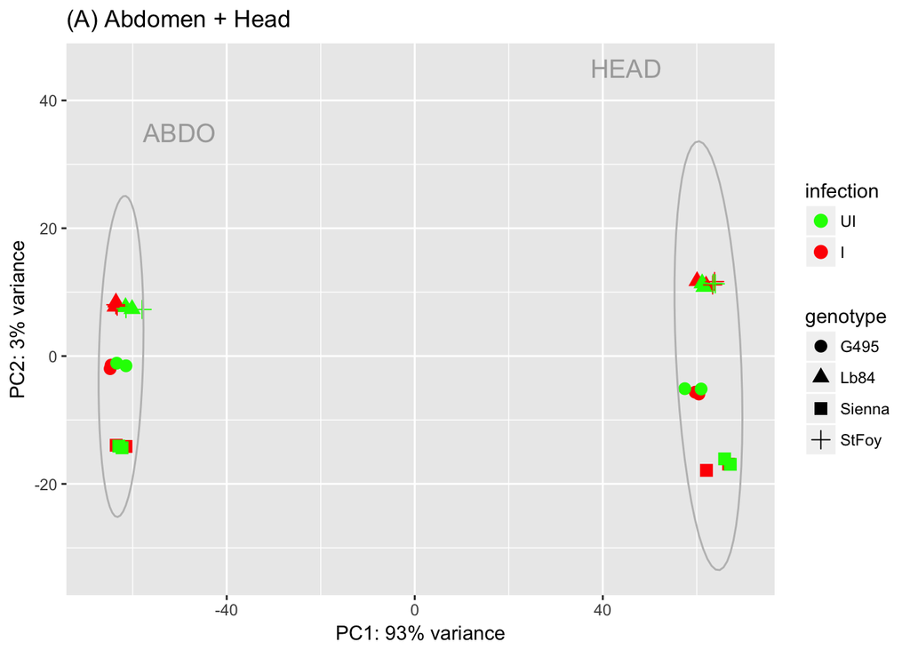

```r
rld <- rlog(dds)
# remove LbFV loci
rld2=rld[-c(1:108),]

data1 <- plotPCA(rld2, intgroup=c("tissue", "genotype","infection"), returnData=TRUE)
percentVar <- round(100 * attr(data1, "percentVar"))

pca1=ggplot(data1, aes(PC1, PC2)) +
  aes(PC1, PC2, color= infection, shape=genotype)  +
  geom_point(size=3) +
  stat_ellipse(aes(PC1, PC2, group = data1$tissue),type = "norm", col="grey") +
  annotate("text", label = "ABDO", x = -50, y = 35, size = 5, colour = "darkgrey")+
  annotate("text", label = "HEAD", x = 45, y = 45, size = 5, colour = "darkgrey")+
  xlab(paste0("PC1: ",percentVar[1],"% variance")) +
  ylab(paste0("PC2: ",percentVar[2],"% variance")) +
  ggtitle("(A) Abdomen + Head") +scale_color_manual(values = c("green", "red"))
pca1
```

## 5.2 Head only

```r
rld_h=rld2[, grep("H", colnames(rld2))]
dim(rld_h)
```

```
## [1] 16679    16
```

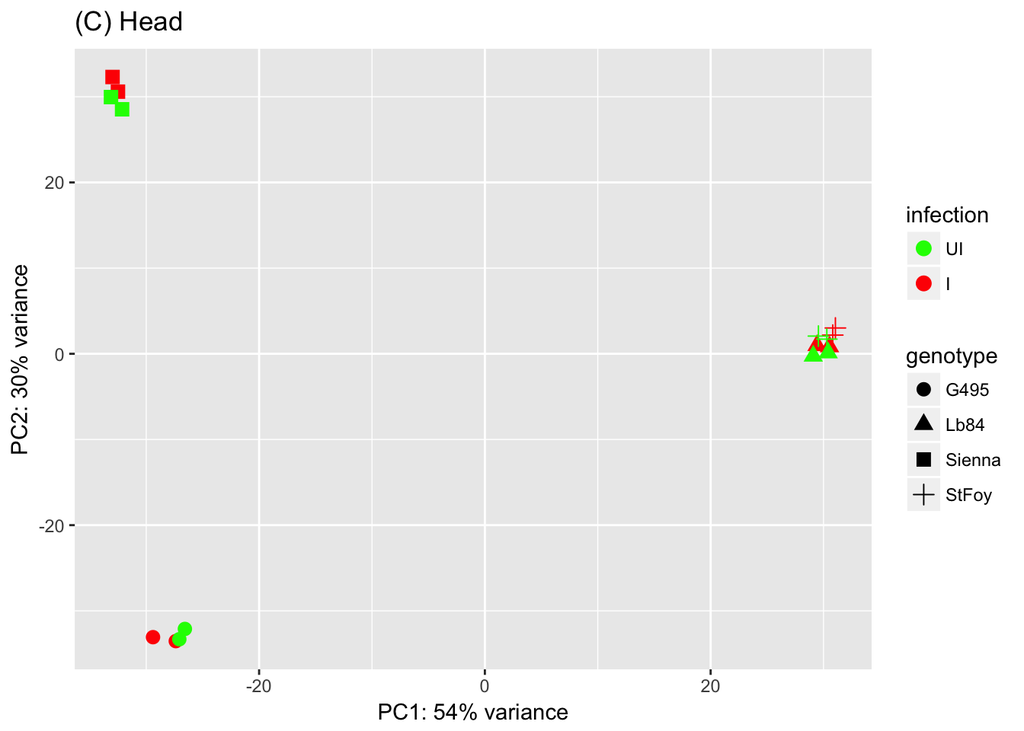

```r
data2 <- plotPCA(rld_h, intgroup=c("genotype","infection"), returnData=TRUE)
percentVar <- round(100 * attr(data2, "percentVar"))
pca2=ggplot(data2, aes(PC1, PC2)) +
  aes(PC1, PC2, color= infection, shape=genotype)  +
  geom_point(size=3) +
  xlab(paste0("PC1: ",percentVar[1],"% variance")) +
  ylab(paste0("PC2: ",percentVar[2],"% variance")) +
  ggtitle("(C) Head")+scale_color_manual(values = c("green", "red"))
pca2
```

## 5.3 Abdomen only

```r
rld_a=rld2[, grep("A", colnames(rld2))]
dim(rld_a)
```

```
## [1] 16679    16
```

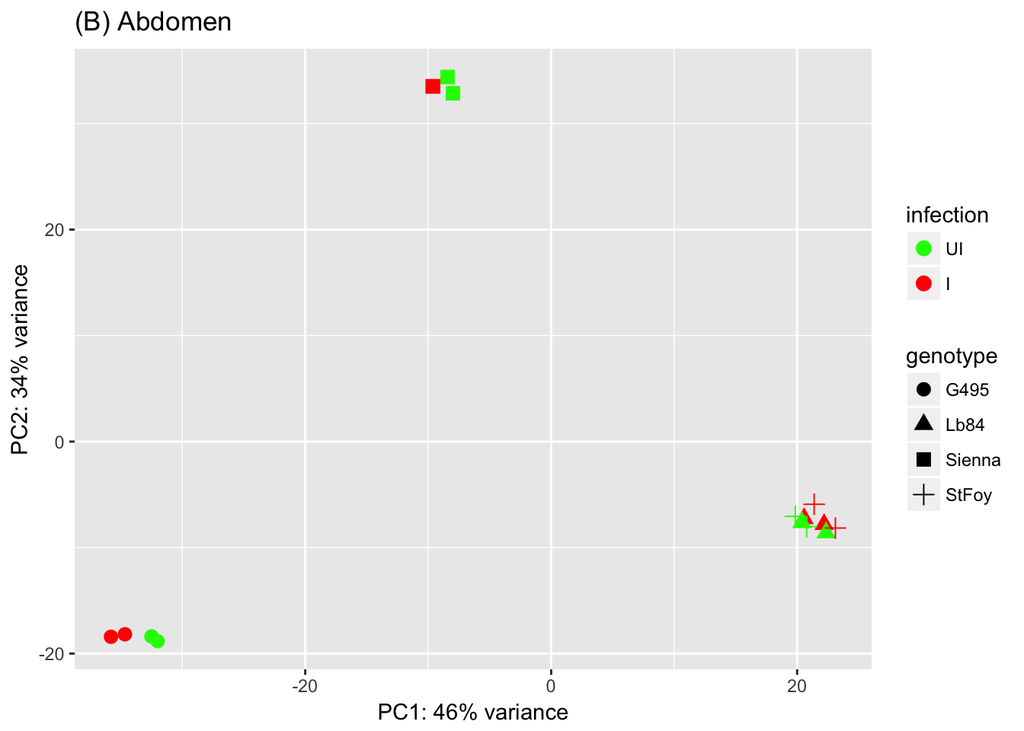

```r
data3 <- plotPCA(rld_a, intgroup=c("genotype","infection"), returnData=TRUE)
percentVar <- round(100 * attr(data3, "percentVar"))
pca3=ggplot(data3, aes(PC1, PC2)) +
  aes(PC1, PC2, color= infection, shape=genotype)  +
  geom_point(size=3) +
  xlab(paste0("PC1: ",percentVar[1],"% variance")) +
  ylab(paste0("PC2: ",percentVar[2],"% variance")) +
  ggtitle("(B) Abdomen")+scale_color_manual(values = c("green", "red"))

pca3
```

# 6 Sample to sample distance

## 6.1 on the full dataset

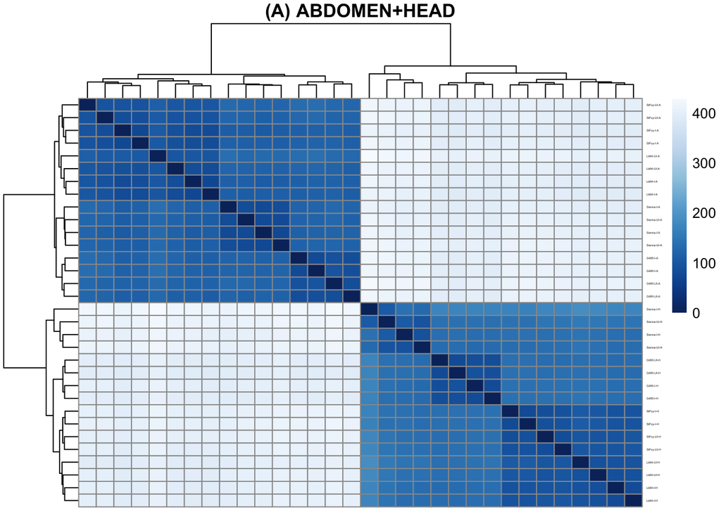

```r
# remove LbFV loci and calculate distance
sampleDists <- dist(t(assay(normTransform(dds[-c(1:108),]))))  # data normalized by log2(x+1)

sampleDistMatrix <- as.matrix(sampleDists)
rownames(sampleDistMatrix) <- paste(dds$genotype, dds$infection,dds$tissue, sep="-")
colnames(sampleDistMatrix) <- NULL
colors <- colorRampPalette( rev(brewer.pal(9, "Blues")) )(255)
clustering1=pheatmap(sampleDistMatrix,
         clustering_distance_rows=sampleDists,
         clustering_distance_cols=sampleDists,
         col=colors, main = "(A) ABDOMEN+HEAD",
          fontsize_row=2)
```

## 6.2 on the abdomen only

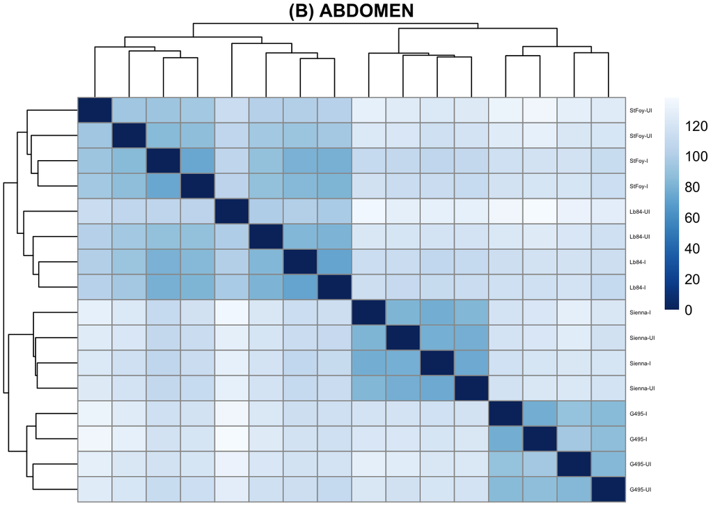

```r
dds_subset=dds[-c(1:108), grep("A", colnames(dds))]
sampleDists <- dist(t(assay(normTransform(dds_subset)))) # data normalized by log2(x+1)
sampleDistMatrixA <- as.matrix(sampleDists)
rownames(sampleDistMatrixA) <- paste(dds_subset$genotype, dds_subset$infection, sep="-")
colnames(sampleDistMatrixA) <- NULL
colors <- colorRampPalette( rev(brewer.pal(9, "Blues")) )(255)
clustering2=pheatmap(sampleDistMatrixA,
         clustering_distance_rows=sampleDists,
         clustering_distance_cols=sampleDists,
         col=colors, main = "(B) ABDOMEN",
          fontsize_row=4)
```

## 6.3 on the head only

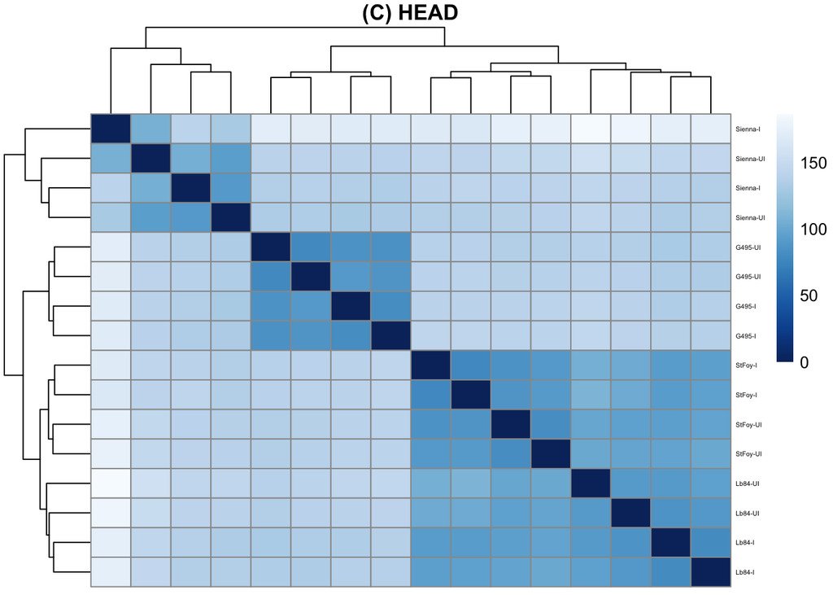

```r
dds_subset=dds[-c(1:108), grep("H", colnames(dds))]
sampleDists <- dist(t(assay(normTransform(dds_subset)))) # data normalized by log2(x+1)
sampleDistMatrixH <- as.matrix(sampleDists)
rownames(sampleDistMatrixH) <- paste(dds_subset$genotype, dds_subset$infection, sep="-")
colnames(sampleDistMatrixH) <- NULL
colors <- colorRampPalette( rev(brewer.pal(9, "Blues")) )(255)
clustering3=pheatmap(sampleDistMatrixH,
         clustering_distance_rows=sampleDists,
         clustering_distance_cols=sampleDists,
         col=colors, main = "(C) HEAD",
          fontsize_row=4)
```

# 7 Differential analysis on wasp genes

## 7.1 using interaction tissue x infection testing by LRT

```r
dim(dds)
```

```
## [1] 16787    32
```

```r
# remove LbFV loci
dds_wasp=dds[-c(1:108),]
dds_wasp
```

```
## class: DESeqDataSet
## dim: 16679 32
## metadata(1): version
## assays(1): counts
## rownames(16679): XLOC_000001 XLOC_000002 ... XLOC_016696
##   XLOC_016697
## rowData names(0):
## colnames(32): G495IA1 G495IA2 ... StFoyUIH1 StFoyUIH2
## colData names(4): genotype tissue infection sizeFactor
```

```r
dim(dds_wasp)
```

```
## [1] 16679    32
```

```r
tab_counts_wasp=assay(dds_wasp)
head(tab_counts_wasp)
```

```
##             G495IA1 G495IA2 G495IH1 G495IH2 G495UIA1 G495UIA2 G495UIH1
## XLOC_000001       0       0      13       4        0        0        5
## XLOC_000002       9      16    1707    1572        8       12     1390
## XLOC_000003      65     105      19      20       60      105       24
## XLOC_000004     153     175     149     109      128      251      129
## XLOC_000005       5       3       9       3        3        8        1
## XLOC_000006     475     590    1966    1671      341      678     1540
##             G495UIH2 Lb84IA1 Lb84IA2 Lb84IH1 Lb84IH2 Lb84UIA1 Lb84UIA2
## XLOC_000001        3       0       0       0       0        0        0
## XLOC_000002     1295       9      14    1192    1471        5        8
## XLOC_000003       18     169     267      15      32       80      166
## XLOC_000004      128     219     289     121     143      105      165
## XLOC_000005        3       1       7       2       3        1        1
## XLOC_000006     1491     729     981    2321    2446      297      555
##             Lb84UIH1 Lb84UIH2 SiennaIA1 SiennaIA2 SiennaIH1 SiennaIH2
## XLOC_000001        0        0         0         0         3         0
## XLOC_000002      791      840        11        10      1950      1435
## XLOC_000003       22       29       198       136        22        18
## XLOC_000004      107      101       216       132       164        41
## XLOC_000005        0        1         3         9        10         5
## XLOC_000006     1548     1568       957       910      3612      1876
##             SiennaUIA1 SiennaUIA2 SiennaUIH1 SiennaUIH2 StFoyIA1 StFoyIA2
## XLOC_000001          0          0          1          1        0        0
## XLOC_000002         34         13       2137       1999       19       19
## XLOC_000003        221        157         27         30      186      194
## XLOC_000004        216        181         81        142      245      210
## XLOC_000005          5          2          8         13       11        3
## XLOC_000006       1144        893       2880       3408      889      731
##             StFoyIH1 StFoyIH2 StFoyUIA1 StFoyUIA2 StFoyUIH1 StFoyUIH2
## XLOC_000001        0        1         1         0         1         1
## XLOC_000002     1380     1763         8         7      1314      1187
## XLOC_000003       26       31        80       109        17        12
## XLOC_000004      122      155       109       145        99        93
## XLOC_000005        2        1         1         1         3         1
## XLOC_000006     2062     2383       357       454      1908      1670
```

```r
summary(rowSums(tab_counts_wasp))
```

```
##    Min. 1st Qu.  Median    Mean 3rd Qu.    Max.
##       0     184    1606   19510   13760 4366000
```

```r
# run analysis on the full model and compare likelihood with reduced one without infection:tissue
design(dds_wasp)
```

```
## ~genotype + tissue + infection + tissue:genotype + genotype:infection +
##     tissue:infection
```

```r
dds_reduced <- DESeq(dds_wasp, test="LRT", reduced=~  genotype + tissue + infection + tissue:genotype + genotype:infection)
res_reduced=results(dds_reduced)
summary(res_reduced)
```

```
##
## out of 16400 with nonzero total read count
## adjusted p-value < 0.1
## LFC > 0 (up)     : 3, 0.018%
## LFC < 0 (down)   : 15, 0.091%
## outliers [1]     : 0, 0%
## low counts [2]   : 6671, 41%
## (mean count < 21)
## [1] see 'cooksCutoff' argument of ?results
## [2] see 'independentFiltering' argument of ?results
```

```r
candidates_LRT=rownames(res_reduced[which(res_reduced$padj<0.05),])
write.table(candidates_LRT, file = "../output/candidates_interaction_analysis.txt", quote=F, row.names = F, col.names = F)
```

## 7.2 using separate analysis on head and abdomen

I split the dataset in two :abdomen/head. I then test infection effect, accounting for genotype effect. We choose to test the infection factor by the classical Wald test (instead of LRT test). I checked that LRT tests gave almost the same candidate lists.

### 7.2.1 Subset data

```r
# subset to abdomen / head
countData_A=countData[,grep(pattern = "A", x = colnames(countData))]
countData_H=countData[,grep(pattern = "H", x = colnames(countData))]
colnames(countData_A)
```

```
##  [1] "G495IA1"    "G495IA2"    "G495UIA1"   "G495UIA2"   "Lb84IA1"
##  [6] "Lb84IA2"    "Lb84UIA1"   "Lb84UIA2"   "SiennaIA1"  "SiennaIA2"
## [11] "SiennaUIA1" "SiennaUIA2" "StFoyIA1"   "StFoyIA2"   "StFoyUIA1"
## [16] "StFoyUIA2"
```

```r
colnames(countData_H)
```

```
##  [1] "G495IH1"    "G495IH2"    "G495UIH1"   "G495UIH2"   "Lb84IH1"
##  [6] "Lb84IH2"    "Lb84UIH1"   "Lb84UIH2"   "SiennaIH1"  "SiennaIH2"
## [11] "SiennaUIH1" "SiennaUIH2" "StFoyIH1"   "StFoyIH2"   "StFoyUIH1"
## [16] "StFoyUIH2"
```

```r
# define factors
colData_A = colData[which(colData$tissue=="A"),-2]
colData_H = colData[which(colData$tissue=="H"),-2]
```

### 7.2.2 Head analysis

```r
dds_head = DESeqDataSetFromMatrix(countData = countData_H,
                             colData = colData_H,
                             design = ~ genotype + infection:genotype + infection)

design(dds_head)
```

```
## ~genotype + infection:genotype + infection
```

```r
# define the reference level for factors:
dds_head$infection <- relevel(dds_head$infection, ref = "UI")
dds_head$genotype # OK G495 is the reference level
```

```
##  [1] G495   G495   G495   G495   Lb84   Lb84   Lb84   Lb84   Sienna Sienna
## [11] Sienna Sienna StFoy  StFoy  StFoy  StFoy
## Levels: G495 Lb84 Sienna StFoy
```

```r
# estimate size factors
dds_head = estimateSizeFactors(object = dds_head)
sizeFactors(dds_head)
```

```
##    G495IH1    G495IH2   G495UIH1   G495UIH2    Lb84IH1    Lb84IH2
##  1.2765230  1.1241699  1.0347999  0.9546346  1.0592503  1.1612990
##   Lb84UIH1   Lb84UIH2  SiennaIH1  SiennaIH2 SiennaUIH1 SiennaUIH2
##  0.7830423  0.8066608  1.3449918  0.6629537  1.0265746  1.2076330
##   StFoyIH1   StFoyIH2  StFoyUIH1  StFoyUIH2
##  0.9641394  1.2070866  1.0206151  0.8873687
```

```r
# remove LbFV loci
dds_head=dds_head[-c(1:108),]
dim(dds_head)
```

```
## [1] 16679    16
```

```r
# adjust the full model
dds_head=DESeq(dds_head)
# Wald tests for infection
res_head=results(dds_head, contrast = c("infection", "I", "UI"))
summary(res_head)
```

```
##
## out of 16250 with nonzero total read count
## adjusted p-value < 0.1
## LFC > 0 (up)     : 63, 0.39%
## LFC < 0 (down)   : 13, 0.08%
## outliers [1]     : 0, 0%
## low counts [2]   : 5034, 31%
## (mean count < 11)
## [1] see 'cooksCutoff' argument of ?results
## [2] see 'independentFiltering' argument of ?results
```

```r
# effect of infection for each genotype:
G495=results(object = dds_head, contrast = c("infection", "I", "UI")) # effect for G495 (reference)
Lb84=results(object = dds_head, contrast = list(c("infection_I_vs_UI", "genotypeLb84.infectionI"))) # effect for Lb84
Sienna=results(object = dds_head, contrast = list(c("infection_I_vs_UI", "genotypeSienna.infectionI"))) # effect for Sienna
StFoy=results(object = dds_head, contrast = list(c("infection_I_vs_UI", "genotypeStFoy.infectionI"))) # effect for StFoy

virus_effect_head=data.frame(G495_virus_effect_head=G495$log2FoldChange,
                             Lb84_virus_effect_head=Lb84$log2FoldChange,
                             Sienna_virus_effect_head=Sienna$log2FoldChange,
                             StFoy_virus_effect_head=StFoy$log2FoldChange)

rownames(virus_effect_head)=rownames(dds_head)
head(virus_effect_head)
```

```
##             G495_virus_effect_head Lb84_virus_effect_head
## XLOC_000001             0.78741607             -0.4807983
## XLOC_000002             0.01893922              0.2217054
## XLOC_000003            -0.36964028             -0.6114859
## XLOC_000004            -0.27407388             -0.1409662
## XLOC_000005             1.27301058              1.8363152
## XLOC_000006            -0.01078247              0.1322609
##             Sienna_virus_effect_head StFoy_virus_effect_head
## XLOC_000001               0.52294911              -1.2054334
## XLOC_000002              -0.05144803               0.1397766
## XLOC_000003              -0.28505432               0.7963839
## XLOC_000004              -0.06037120               0.3383587
## XLOC_000005              -0.31422257              -0.5576292
## XLOC_000006              -0.03023007               0.1321099
```

From this analysis, we choose to select the loci for which the virus effect was significant at 0.05 and for which the virus has consistent effect on all four genotypes (measured by the value of the infection parameter for each genotype).

```r
candidates_head_up_wald=rownames(res_head[which(res_head$padj<0.05 &
                                                  res_head$log2FoldChange>0 &
                                                  rowSums(virus_effect_head > 0) == 4),])


candidates_head_down_wald=rownames(res_head[which(res_head$padj<0.05 &
                                                  res_head$log2FoldChange<0 &
                                                  rowSums(virus_effect_head < 0) == 4),])


candidates_head_wald=c(candidates_head_up_wald,candidates_head_down_wald)

length(candidates_head_wald)
```

```
## [1] 19
```

```r
length(candidates_head_up_wald)
```

```
## [1] 17
```

```r
length(candidates_head_down_wald)
```

```
## [1] 2
```

```r
write.table(candidates_head_up_wald, file = "../output/candidates_head_up_separate_analysis.txt", quote=F, row.names = F, col.names = F)
write.table(candidates_head_down_wald, file = "../output/candidates_head_down_separate_analysis.txt", quote=F, row.names = F, col.names = F)
write.table(x = as.data.frame(res_head), file = "../output/separate_analysis.head.txt", quote=F, row.names = T, col.names=T)
```

### 7.2.3 Abdomen analysis

```r
dds_abdo = DESeqDataSetFromMatrix(countData = countData_A,
                             colData = colData_A,
                             design = ~ genotype + infection:genotype + infection)

design(dds_abdo)
```

```
## ~genotype + infection:genotype + infection
```

```r
# define the reference level for factors:
dds_abdo$infection <- relevel(dds_abdo$infection, ref = "UI")
dds_abdo$genotype # OK G495 is the reference level
```

```
##  [1] G495   G495   G495   G495   Lb84   Lb84   Lb84   Lb84   Sienna Sienna
## [11] Sienna Sienna StFoy  StFoy  StFoy  StFoy
## Levels: G495 Lb84 Sienna StFoy
```

```r
# estimate size factors
dds_abdo = estimateSizeFactors(object = dds_abdo)
sizeFactors(dds_abdo)
```

```
##    G495IA1    G495IA2   G495UIA1   G495UIA2    Lb84IA1    Lb84IA2
##  0.9437011  1.0960284  0.6786213  1.3462602  1.1911095  1.5862597
##   Lb84UIA1   Lb84UIA2  SiennaIA1  SiennaIA2 SiennaUIA1 SiennaUIA2
##  0.4781940  1.0007291  1.2448106  1.0787642  1.4106408  1.1869103
##   StFoyIA1   StFoyIA2  StFoyUIA1  StFoyUIA2
##  1.2915890  1.1684015  0.5252233  0.7431815
```

```r
# remove LbFV loci
dds_abdo=dds_abdo[-c(1:108),]
dim(dds_abdo)
```

```
## [1] 16679    16
```

```r
# adjust the full model
dds_abdo=DESeq(dds_abdo)
# Wald tests for infection
res_abdo=results(dds_abdo, contrast = c("infection", "I", "UI"))
summary(res_abdo)
```

```
##
## out of 15610 with nonzero total read count
## adjusted p-value < 0.1
## LFC > 0 (up)     : 247, 1.6%
## LFC < 0 (down)   : 241, 1.5%
## outliers [1]     : 0, 0%
## low counts [2]   : 6634, 42%
## (mean count < 10)
## [1] see 'cooksCutoff' argument of ?results
## [2] see 'independentFiltering' argument of ?results
```

```r
# effect of infection for each genotype:
G495=results(object = dds_abdo, contrast = c("infection", "I", "UI")) # effect for G495 (reference)
Lb84=results(object = dds_abdo, contrast = list(c("infection_I_vs_UI", "genotypeLb84.infectionI"))) # effect for Lb84
Sienna=results(object = dds_abdo, contrast = list(c("infection_I_vs_UI", "genotypeSienna.infectionI"))) # effect for Sienna
StFoy=results(object = dds_abdo, contrast = list(c("infection_I_vs_UI", "genotypeStFoy.infectionI"))) # effect for StFoy

virus_effect_abdo=data.frame(G495_virus_effect_abdo=G495$log2FoldChange, Lb84_virus_effect_abdo=Lb84$log2FoldChange, Sienna_virus_effect_abdo=Sienna$log2FoldChange, StFoy_virus_effect_abdo=StFoy$log2FoldChange)

rownames(virus_effect_abdo)=rownames(dds_abdo)
head(virus_effect_abdo)
```

```
##             G495_virus_effect_abdo Lb84_virus_effect_abdo
## XLOC_000001           -0.089729006            -0.99056533
## XLOC_000002            0.258238234            -0.12798284
## XLOC_000003            0.005459783            -0.09846766
## XLOC_000004           -0.220392556            -0.04316423
## XLOC_000005           -0.398392262             0.94060514
## XLOC_000006            0.050945302             0.07633098
##             Sienna_virus_effect_abdo StFoy_virus_effect_abdo
## XLOC_000001               0.15911039             -2.62353154
## XLOC_000002              -0.96495394              0.35687464
## XLOC_000003              -0.01854012              0.05304300
## XLOC_000004              -0.04137821             -0.12084657
## XLOC_000005               1.01025623              1.80738816
## XLOC_000006               0.04282496              0.03119629
```

From this analysis, we choose to select the loci for which the virus effect was significant at 0.05 and for which the virus has consistent effect on all four genotypes (measured by the value of the infection parameter for each genotype).

```r
candidates_abdo_up_wald=rownames(res_abdo[which(res_abdo$padj<0.05 &
                                                  res_abdo$log2FoldChange>0 &
                                                  rowSums(virus_effect_abdo > 0) == 4),])

candidates_abdo_down_wald=rownames(res_abdo[which(res_abdo$padj<0.05 &
                                                  res_abdo$log2FoldChange<0 &
                                                  rowSums(virus_effect_abdo < 0) == 4),])

candidates_abdo_wald=c(candidates_abdo_up_wald,candidates_abdo_down_wald)


length(candidates_abdo_wald)
```

```
## [1] 137
```

```r
length(candidates_abdo_up_wald)
```

```
## [1] 78
```

```r
length(candidates_abdo_down_wald)
```

```
## [1] 59
```

```r
write.table(candidates_abdo_up_wald, file = "../output/candidates_abdo_up_separate_analysis.txt", quote=F, row.names = F, col.names = F)
write.table(candidates_abdo_down_wald, file = "../output/candidates_abdo_down_separate_analysis.txt", quote=F, row.names = F, col.names = F)
write.table(x = as.data.frame(res_abdo), file = "../output/separate_analysis.abdo.txt", quote=F, row.names = T, col.names=T)
```

### 7.2.4 Compare the candidate lists

#### 7.2.4.1 Head and abdomen detected by separate analysis by tissue

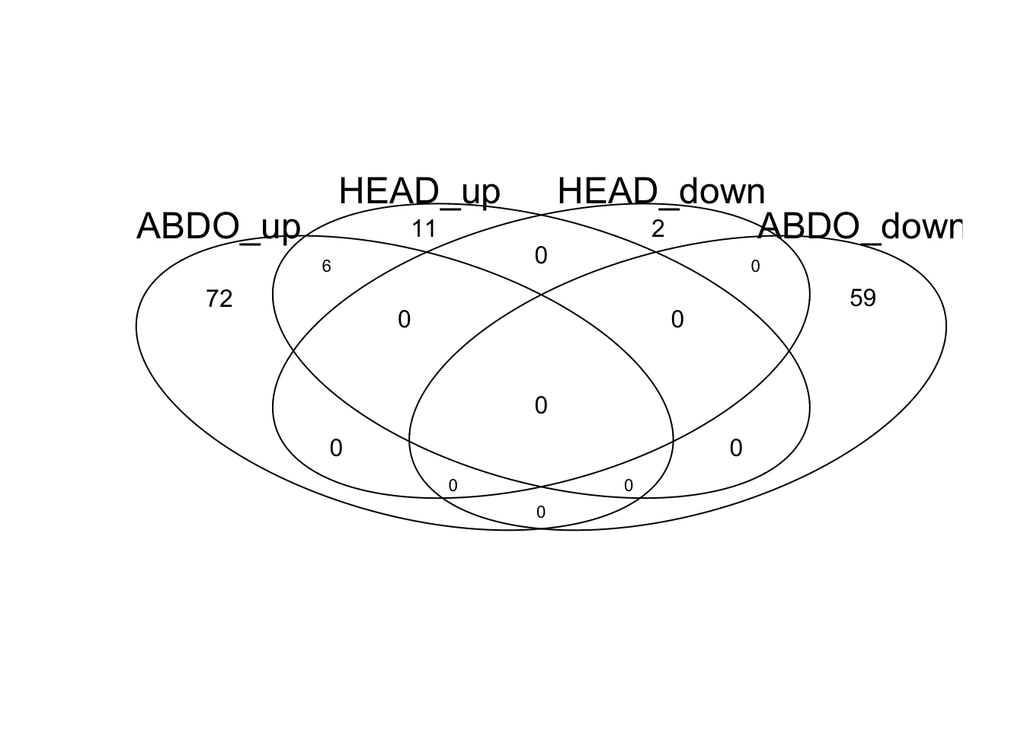

```r
venn( list(ABDO_up=candidates_abdo_up_wald, HEAD_up=candidates_head_up_wald, HEAD_down=candidates_head_down_wald, ABDO_down=candidates_abdo_down_wald) )
```

```r
# special cases :
# up regulated in both head and abdomen:
intersect(candidates_abdo_up_wald, candidates_head_up_wald)
```

```
## [1] "XLOC_002310" "XLOC_002555" "XLOC_008031" "XLOC_011296" "XLOC_015655"
## [6] "XLOC_016381"
```

#### 7.2.4.2 Head and abdomen candidates detected by separate analysis by tissue or by the interaction approach

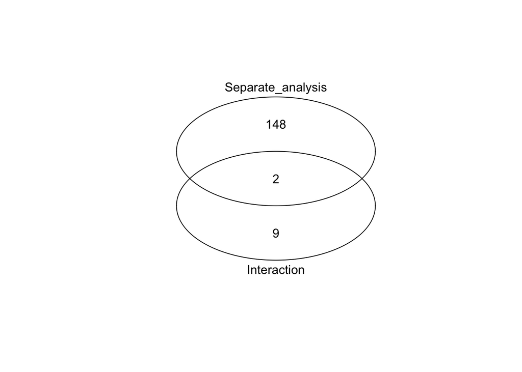

```r
Separate_analysis=unique(c(candidates_abdo_wald, candidates_head_wald))
venn( list(Interaction=candidates_LRT, Separate_analysis=Separate_analysis))
```

```r
intersect=intersect(candidates_LRT, Separate_analysis)
union=union(candidates_LRT, Separate_analysis)
separate_specific=setdiff(Separate_analysis, candidates_LRT)
interaction_specific=setdiff(candidates_LRT, Separate_analysis)
length(union)
```

```
## [1] 159
```

```r
length(separate_specific)
```

```
## [1] 148
```

```r
length(interaction_specific)
```

```
## [1] 9
```

#### 7.2.4.3 Look to some genes

import TPM values (output of stringtie)

```r
tpm=read.table("../output/TPM.txt")
dim(tpm)
```

```
## [1] 16787    32
```

```r
head(tpm)
```

```
##         G495IA1   G495IA2   G495IH1   G495IH2 G495UIA1 G495UIA2 G495UIH1
## ORF1  1.8490959 1.0837939 0.4595979 1.0126184        0        0        0
## ORF2  0.0000000 0.0000000 0.0000000 0.2395523        0        0        0
## ORF3  0.0000000 0.0000000 1.3744578 0.0000000        0        0        0
## ORF4 11.2391213 4.8139312 3.6530573 4.0243367        0        0        0
## ORF5  0.7008171 0.1232291 0.1045140 0.2302726        0        0        0
## ORF6  0.0000000 0.0000000 0.0000000 0.0000000        0        0        0
##      G495UIH2   Lb84IA1    Lb84IA2    Lb84IH1  Lb84IH2 Lb84UIA1 Lb84UIA2
## ORF1        0 0.4984264  1.5578737  1.7674061 1.363393        0        0
## ORF2        0 0.0000000  0.0000000  0.0000000 0.000000        0        0
## ORF3        0 0.0000000  3.4941932  0.0000000 0.000000        0        0
## ORF4        0 7.2242416 11.6541822 11.0180478 9.179378        0        0
## ORF5        0 0.9067498  0.4428318  0.8038274 0.248032        0        0
## ORF6        0 0.0000000  0.0000000  0.0000000 0.000000        0        0
##      Lb84UIH1 Lb84UIH2 SiennaIA1  SiennaIA2  SiennaIH1 SiennaIH2
## ORF1        0        0 0.4519389  1.9267591 1.19883215 3.9594601
## ORF2        0        0 0.0000000  0.0000000 0.00000000 0.0000000
## ORF3        0        0 2.7031062  1.6463144 0.00000000 1.8216965
## ORF4        0        0 6.5504476 13.1268076 5.04464324 7.1202000
## ORF5        0        0 0.7194063  1.7526044 0.09087274 0.1385221
## ORF6        0        0 0.3893061  0.4742101 0.00000000 0.0000000
##      SiennaUIA1 SiennaUIA2 SiennaUIH1 SiennaUIH2   StFoyIA1   StFoyIA2
## ORF1          0          0          0          0  2.1569895  1.5848380
## ORF2          0          0          0          0  0.0000000  0.0000000
## ORF3          0          0          0          0  1.4334710  4.7395626
## ORF4          0          0          0          0 10.9814873 10.6209076
## ORF5          0          0          0          0  0.6540083  1.8019858
## ORF6          0          0          0          0  0.0000000  0.9101334
##       StFoyIH1 StFoyIH2 StFoyUIA1 StFoyUIA2 StFoyUIH1 StFoyUIH2
## ORF1 0.9310947 2.671146         0         0         0         0
## ORF2 0.0000000 0.000000         0         0         0         0
## ORF3 0.0000000 0.000000         0         0         0         0
## ORF4 9.8675897 6.130958         0         0         0         0
## ORF5 0.0000000 0.000000         0         0         0         0
## ORF6 0.0000000 0.000000         0         0         0         0
```

Two functions to plot individual genes

```r
# function to extract tpm values for a given locus
get_TPM=function(locus="MSTRG.10"){
  row=t(tpm[row.names(tpm)==locus,])
  tpm_A=row[grep("A", row.names(row)),]
  tpm_H=row[grep("H", row.names(row)),]

  genotype= colData[colData$tissue=="A",]$genotype
  infection= colData[colData$tissue=="A",]$infection
  data_abdo=data.frame(tpm_A, genotype, infection)
  data_head=data.frame(tpm_H, genotype, infection)
  names(data_abdo)[1]="tpm"
  names(data_head)[1]="tpm"
  data_abdo_means=tapply(X = tpm_A , INDEX = list(genotype, infection), FUN = mean, simplify = T)
  data_head_means=tapply(X = tpm_H , INDEX = list(genotype, infection), FUN = mean, simplify = T)
  # order factors
  data_abdo$infection=factor(x = data_abdo$infection, levels=c("UI", "I"))
  data_head$infection=factor(x = data_head$infection, levels=c("UI", "I"))
  res=list(data_abdo, data_head, data_abdo_means, data_head_means)
  return(res)
}
```

```r
ggplot_function=function(dataset=tpm, gene="MSTRG.10", tissue="A", size=1, size_title=10, size_points=3, legend=TRUE, xlab=FALSE, ylab=FALSE){

# extract data for a given locus
data_locus_i=get_TPM(locus = gene)

if (tissue=="A"){
  d=data_locus_i[[1]]
  means=data_locus_i[[3]]
}

if (tissue=="H"){
  d=data_locus_i[[2]]
  means=data_locus_i[[4]]
}

# plot the data
  # plot the data
if (legend==TRUE) {
  p  = ggplot(data = d , aes(x=infection, y=tpm, fill=genotype)) + scale_fill_manual(values=c("blue", "black", "red","green"), name="")
  }
if (legend==FALSE) {
    p  = ggplot(d , aes(x=infection, y=tpm, fill=genotype)) + scale_fill_manual(values=c("blue", "black", "red","green"))+ theme (legend.position="none")
}
   p  = p  + geom_point(shape=21, size=size_points, position = position_jitter(width = 0.1, height = 0))
   p  = p  + geom_segment(aes(x="UI", xend="I", yend=means[1,1], y=means[1,2]), colour="blue", size=size)
    p  = p  + geom_segment(aes(x="UI", xend="I", yend=means[2,1], y=means[2,2]), colour="black", size=size)
   p  = p  + geom_segment(aes(x="UI", xend="I", yend=means[3,1], y=means[3,2]), colour="red", size=size)
   p  = p  + geom_segment(aes(x="UI", xend="I", yend=means[4,1], y=means[4,2]), colour="green", size=size)
   p  =  p  + ggtitle(paste(gene, tissue))

      if (ylab==TRUE & xlab==TRUE) {
   p  =  p  + theme (axis.text=element_text(size=size_title), axis.title=element_text(size=size_title), plot.title=element_text(size=size_title), legend.title=element_blank())}
   if (ylab==FALSE & xlab==TRUE) {
   p  =  p  + theme (axis.text=element_text(size=size_title), axis.title=element_text(size=size_title), axis.title.y=element_blank(), plot.title=element_text(size=size_title), legend.title=element_blank())}
      if (ylab==TRUE & xlab==FALSE) {
   p  =  p  + theme (axis.text=element_text(size=size_title), axis.title=element_text(size=size_title), axis.title.x=element_blank(), plot.title=element_text(size=size_title), legend.title=element_blank())}
      if (ylab==FALSE & xlab==FALSE) {
   p  =  p  + theme (axis.text=element_text(size=size_title), axis.title=element_text(size=size_title), axis.title.x=element_blank(), axis.title.y=element_blank(),  plot.title=element_text(size=size_title), legend.title=element_blank())}

   p  =  p  + labs(x = "infection", y="TPM")

return(p)

}
```

### 7.2.5 Genes common to both approches

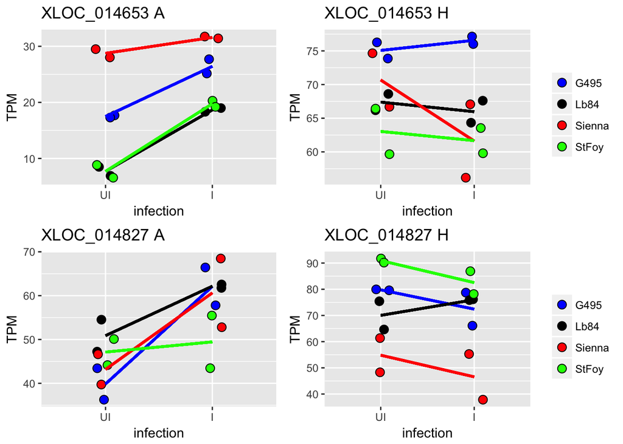

```r
plot_intersect_A=list()
plot_intersect_H=list()

for (i in 1:length(intersect)){
plot_intersect_A[[i]]=ggplot_function(gene = intersect[i],tissue = "A", legend = F, xlab = "infection",ylab = "TPM")
plot_intersect_H[[i]]=ggplot_function(gene = intersect[i],tissue = "H", legend = T, xlab = "infection",ylab = "TPM")
}
grid.arrange(plot_intersect_A[[1]], plot_intersect_H[[1]],
             plot_intersect_A[[2]], plot_intersect_H[[2]],
          #   plot_intersect_A[[3]], plot_intersect_H[[3]],
           #  plot_intersect_A[[4]], plot_intersect_H[[4]],
            # plot_intersect_A[[5]], plot_intersect_H[[5]],
             nrow = 2, ncol=2, widths = c(1,1.2))
```

```r
dev.copy2pdf(file="../figures/Genes_both_analysis.pdf")
```

### 7.2.6 Genes found by the separate analysis but not by the interaction

```r
plot_separate_A=list()
plot_separate_H=list()

for (i in 1:length(separate_specific)){
plot_separate_A[[i]]=ggplot_function(gene = separate_specific[i],tissue = "A", legend = F, ylab = T,size_title = 5, size_points = 2, xlab=F)
plot_separate_H[[i]]=ggplot_function(gene = separate_specific[i],tissue = "H", legend = T, size_title = 5, size_points = 2)
}

pdf(file = "../figures/Genes_separate_analysis.pdf", width = 5)
sequence=seq.int(from = 1, to = length(separate_specific), by = 5)
sequence=sequence[-length(sequence)]

for (i in sequence){
grid.arrange(plot_separate_A[[i]], plot_separate_H[[i]],
             plot_separate_A[[i+1]], plot_separate_H[[i+1]],
             plot_separate_A[[i+2]], plot_separate_H[[i+2]],
             plot_separate_A[[i+3]], plot_separate_H[[i+3]],
             plot_separate_A[[i+4]], plot_separate_H[[i+4]],
             nrow = 5, ncol=2, widths = c(1,1.2))
}
grid.arrange(plot_separate_A[[91]], plot_separate_H[[91]],
                          nrow = 5, ncol=2, widths = c(1,1.2))

dev.off()
```

### 7.2.7 Genes found by the interaction approach but not the separate analysis

```r
plot_interaction_A=list()
plot_interaction_H=list()

for (i in 1:length(interaction_specific)){
plot_interaction_A[[i]]=ggplot_function(gene = interaction_specific[i],tissue = "A", legend = F, ylab = T, size_title = 5, size_points = 2, xlab=F)
plot_interaction_H[[i]]=ggplot_function(gene = interaction_specific[i],tissue = "H", legend = T, size_title = 5, size_points = 2)
}

pdf(file = "../figures/Genes_interaction_analysis.pdf", width=5)
sequence=seq.int(from = 1, to = length(interaction_specific), by = 5)
sequence=sequence[-length(sequence)]

for (i in sequence){
grid.arrange(plot_interaction_A[[i]], plot_interaction_H[[i]],
             plot_interaction_A[[i+1]], plot_interaction_H[[i+1]],
             plot_interaction_A[[i+2]], plot_interaction_H[[i+2]],
             plot_interaction_A[[i+3]], plot_interaction_H[[i+3]],
             plot_interaction_A[[i+4]], plot_interaction_H[[i+4]],
             nrow = 5, ncol=2, widths = c(1,1.2))
}
grid.arrange(plot_interaction_A[[6]], plot_interaction_H[[6]],
             plot_interaction_A[[7]], plot_interaction_H[[7]],
             plot_interaction_A[[8]], plot_interaction_H[[8]],
             plot_interaction_A[[9]], plot_interaction_H[[9]],
             nrow = 5, ncol=2, widths = c(1,1.2))

dev.off()
```

### 7.2.8 classification of genes found by the interaction approach

The plots were indivudally observed and classified as specifically “abdomen”-altered or “head”-altered depending on their profile. We kept genes with consistent trends for all four genotypes and filtered-out the genes showing up-regulation in one tissue and down-regulation in the other. We thus select genes that are specificially altered in one tissue.

```r
# abdomen-altered genes
interaction_specific_abdomen_up=c("XLOC_001153","XLOC_007234", "XLOC_012941", "XLOC_015908")
interaction_specific_abdomen_down=NULL

# head altered genes
interaction_specific_head_up=c("XLOC_002874", "XLOC_008873")
interaction_specific_head_down=c("XLOC_001423", "XLOC_010609", "XLOC_011280")
```

### 7.2.9 Venn graph of the whole sets of candidates

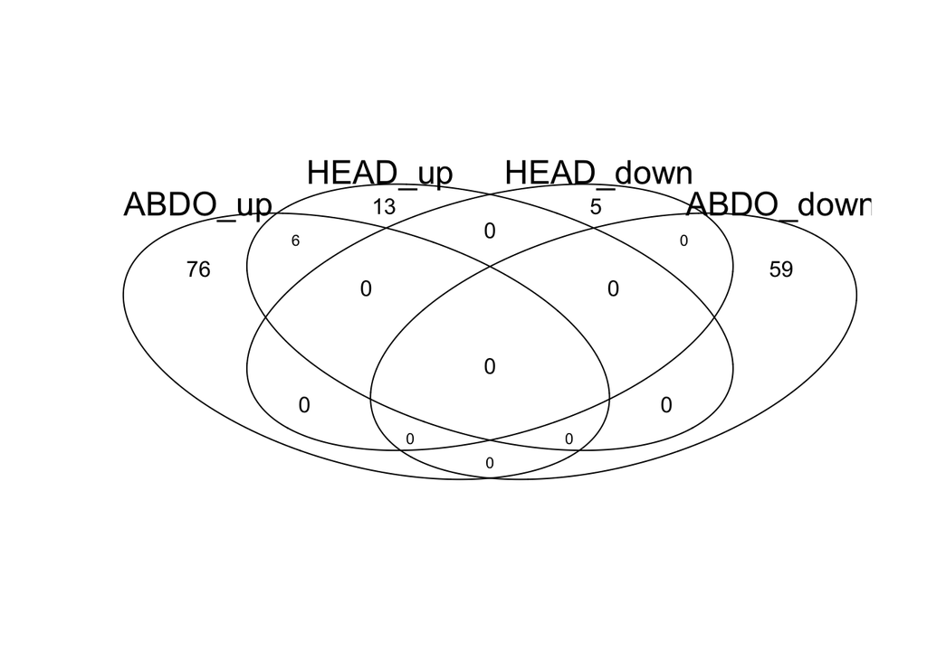

```r
venn( list(ABDO_up=c(candidates_abdo_up_wald, interaction_specific_abdomen_up), HEAD_up=c(candidates_head_up_wald, interaction_specific_head_up), HEAD_down=c(candidates_head_down_wald, interaction_specific_head_down), ABDO_down=c(candidates_abdo_down_wald, interaction_specific_abdomen_down) ))
```

```r
# remove genes both deregulated in abdomen and head
to_remove=intersect(candidates_abdo_up_wald, candidates_head_up_wald)
candidates_abdo_up_final=c(candidates_abdo_up_wald, interaction_specific_abdomen_up)
candidates_abdo_up_final2=setdiff(x = candidates_abdo_up_final, to_remove)
candidates_head_up_final=c(candidates_head_up_wald, interaction_specific_head_up)
candidates_head_up_final2=setdiff(x = candidates_head_up_final, to_remove)

# write the final candidate lists
write.table(candidates_abdo_up_final2, file = "../output/candidates_abdo_up_final.txt", quote=F, row.names = F, col.names = F)
write.table(c(candidates_abdo_down_wald, interaction_specific_abdomen_down), file = "../output/candidates_abdo_down_final.txt", quote=F, row.names = F, col.names = F)
write.table(candidates_head_up_final2, file = "../output/candidates_head_up_final.txt", quote=F, row.names = F, col.names = F)
write.table(c(candidates_head_down_wald, interaction_specific_head_down), file = "../output/candidates_head_down_final.txt", quote=F, row.names = F, col.names = F)
```

# 8 PCA of candidate genes Head only

```r
candidates_head=na.omit(c(candidates_head_up_final2, candidates_head_down_wald, interaction_specific_head_down))
rld_h_candidates=rld_h[which(rownames(rld_h) %in% candidates_head),]

dim(rld_h_candidates)
```

```
## [1] 18 16
```

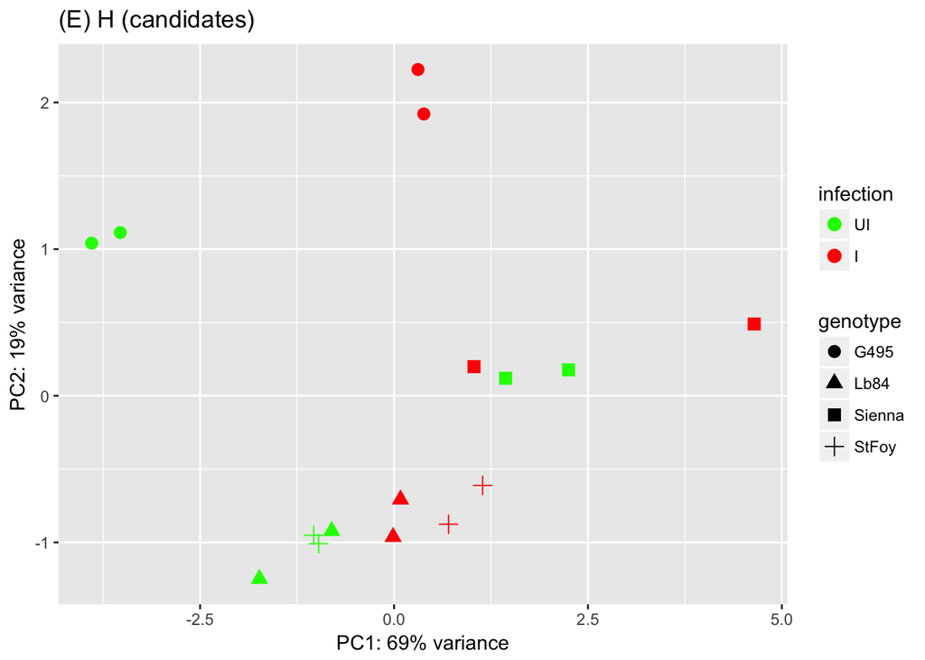

```r
data4 <- plotPCA(rld_h_candidates, intgroup=c("genotype","infection"), returnData=TRUE)
percentVar <- round(100 * attr(data4, "percentVar"))
pca4=ggplot(data4, aes(PC1, PC2)) +
  aes(PC1, PC2, color= infection, shape=genotype)  +
  geom_point(size=3) +
  xlab(paste0("PC1: ",percentVar[1],"% variance")) +
  ylab(paste0("PC2: ",percentVar[2],"% variance")) +
  ggtitle("(E) H (candidates)")+scale_color_manual(values = c("green", "red"))
pca4
```

# 9 PCA of candidate genes ABDO only

```r
candidates_abdo=na.omit(c(candidates_abdo_up_final2, candidates_abdo_down_wald, interaction_specific_abdomen_up))
rld_a_candidates=rld_a[which(rownames(rld_a) %in% candidates_abdo),]

dim(rld_a_candidates)
```

```
## [1] 135  16
```

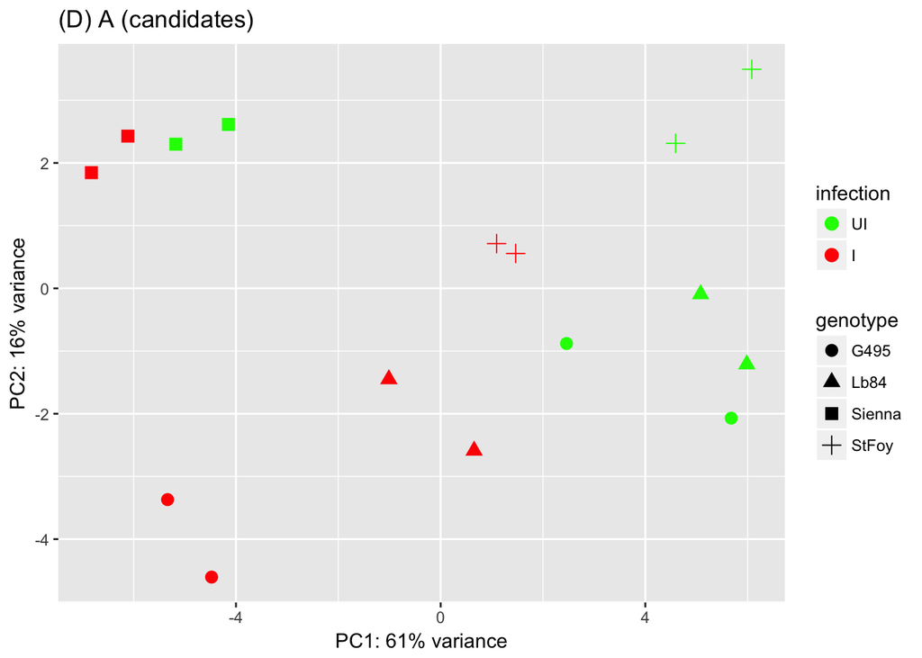

```r
data5 <- plotPCA(rld_a_candidates, intgroup=c("genotype","infection"), returnData=TRUE)
percentVar <- round(100 * attr(data5, "percentVar"))
pca5=ggplot(data5, aes(PC1, PC2)) +
  aes(PC1, PC2, color= infection, shape=genotype)  +
  geom_point(size=3) +
  xlab(paste0("PC1: ",percentVar[1],"% variance")) +
  ylab(paste0("PC2: ",percentVar[2],"% variance")) +
  ggtitle("(D) A (candidates)")+scale_color_manual(values = c("green", "red"))
pca5
```

```r
# figure
lay = rbind (c(1,1), c(2,3), c(4,5))

pdf(file = "../figures/PCAs.pdf", width=5)
grid.arrange(grobs=list(pca1+theme(legend.position="none"), pca3+theme(legend.position="none"), pca2, pca5+theme(legend.position = "none"), pca4+theme(legend.position="none")), layout_matrix=lay, widths=c(1,1.3))
dev.off()
```

# 10 Sample to sample distance for candidate gene sets

## 10.1 abdo

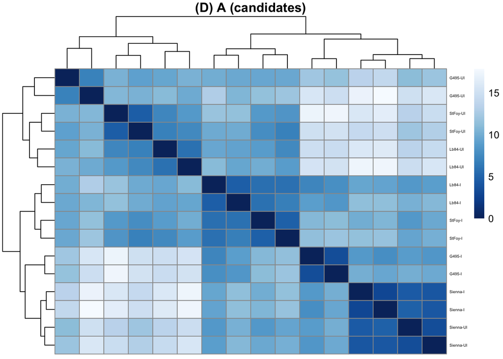

```r
dds_subset=dds[candidates_abdo, grep("A", colnames(dds))]
sampleDists <- dist(t(assay(normTransform(dds_subset)))) # data normalized by log2(x+1)
sampleDistMatrixAc <- as.matrix(sampleDists)
rownames(sampleDistMatrixAc) <- paste(dds_subset$genotype, dds_subset$infection, sep="-")
colnames(sampleDistMatrixAc) <- NULL
colors <- colorRampPalette( rev(brewer.pal(9, "Blues")) )(255)
clustering4=pheatmap(sampleDistMatrixAc,
         clustering_distance_rows=sampleDists,
         clustering_distance_cols=sampleDists,
         col=colors, main = "(D) A (candidates)",
          fontsize_row=4)
```

## 10.2 head

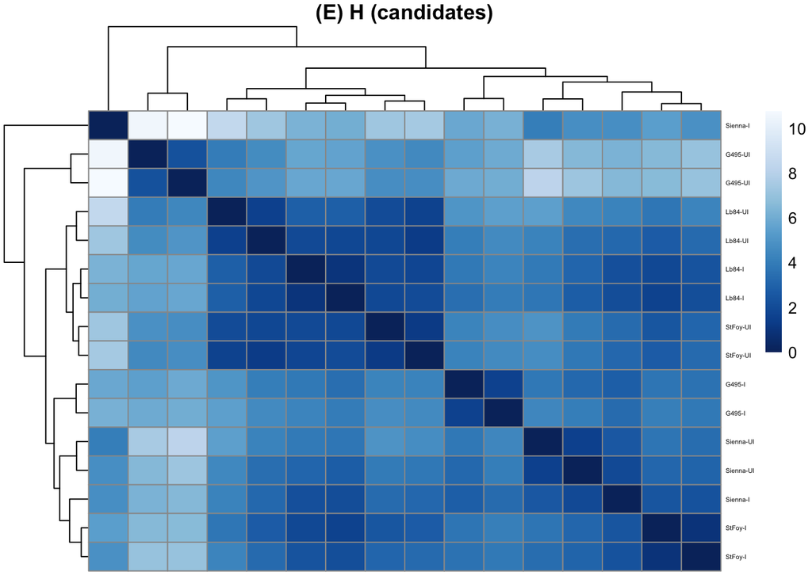

```r
dds_subset=dds[candidates_head, grep("H", colnames(dds))]
sampleDists <- dist(t(assay(normTransform(dds_subset)))) # data normalized by log2(x+1)
sampleDistMatrixHc <- as.matrix(sampleDists)
rownames(sampleDistMatrixHc) <- paste(dds_subset$genotype, dds_subset$infection, sep="-")
colnames(sampleDistMatrixHc) <- NULL
colors <- colorRampPalette( rev(brewer.pal(9, "Blues")) )(255)
clustering5=pheatmap(sampleDistMatrixHc,
         clustering_distance_rows=sampleDists,
         clustering_distance_cols=sampleDists,
         col=colors, main = "(E) H (candidates)",
        fontsize_row=4)
```

Figure

```r
lay = rbind (c(1,1), c(2,3), c(4,5))
pdf(file = "../figures/Clusterings.pdf", width=6)
grid.arrange(grobs=list(clustering1$gtable, clustering2$gtable, clustering3$gtable, clustering4$gtable, clustering5$gtable), layout_matrix=lay, widths=c(1,1))
dev.off()
```

# 11 Plot of individual candidate genes

```r
candidates=c(candidates_abdo_up_final2,
             c(candidates_abdo_down_wald, interaction_specific_abdomen_down),
             candidates_head_up_final2,
             c(candidates_head_down_wald, interaction_specific_head_down)
             )
candidates=na.omit(candidates)
plot_interaction_A=list()
plot_interaction_H=list()

for (i in 1:length(candidates)){
plot_interaction_A[[i]]=ggplot_function(dataset = TPM, gene = candidates[i],tissue = "A", legend = F, ylab = T, size_title = 5, size_points = 2, xlab=F)
plot_interaction_H[[i]]=ggplot_function(dataset = TPM, gene = candidates[i],tissue = "H", legend = T, size_title = 5, size_points = 2)
}

pdf(file = "../figures/Genes_final_set.pdf", width = 5)
sequence=seq.int(from = 1, to = length(candidates), by = 5)

for (i in sequence[-length(sequence)]){
grid.arrange(plot_interaction_A[[i]], plot_interaction_H[[i]],
             plot_interaction_A[[i+1]], plot_interaction_H[[i+1]],
             plot_interaction_A[[i+2]], plot_interaction_H[[i+2]],
             plot_interaction_A[[i+3]], plot_interaction_H[[i+3]],
             plot_interaction_A[[i+4]], plot_interaction_H[[i+4]],
             nrow = 5, ncol=2, widths = c(1,1.2))
}
i=151
grid.arrange(plot_interaction_A[[i]], plot_interaction_H[[i]],
             plot_interaction_A[[i+1]], plot_interaction_H[[i+1]],
             plot_interaction_A[[i+2]], plot_interaction_H[[i+2]],
             nrow = 5, ncol=2, widths = c(1,1.2))
dev.off()
```